# **长期循环**

Averaging regional curves, we see that the overall occupation index of the Latin West (assuming that North Africa followed suit) increased greatly during the first century CE, followed by a more gentle growth in the second century (figure 7.1a, solid line). After the peak in the second century, the occupation index began decreasing during the first half of the third century and hit a minimum in the second half. There was a recovery in the fourth century (during the next cycle of the Dominate), followed by a final collapse in the fifth, when the western Roman Empire was overrun by the Germanic invaders. Regional surveys support this picture. Thus, the Albegna Valley (Etruria) survey found twenty-three farms, villas, and villages in the first century. The number declined to fourteen in the second century and eight in the third. It then increased to eleven in the fourth century and declined again to six in the fifth century (data from Cambi and Fentress, cited in Bintliff and Sbonias 1999:5). This is the same pattern that Lewit found for Italy. Thus, it appears probable that the peak in the rural Italian population was achieved rather early, in the first century, while population in the rest of the empire continued to increase up to the mid-second century.

尽管如此，我们仍然无法将居住指数直接与人口数量联系起来，因为废弃地点并不意味着居住在废弃地点的所有人员都死亡。事实上，我们知道，在滞胀和危机阶段，相当一部分农村人口迁移到城市。另一方面，*农村*土地的占用指数（这是勒维特所关注的）与另一个利益量——承载能力——更直接相关，承载能力定义为在其控制的领土内每年生产的口粮数量。状态。可以用耕地面积乘以单位土地平均生产力来估算（计算示例见第三章附录））。在二世纪的高峰和三世纪末的低谷之间，拉丁西部地区被占用的农村土地数量减少了 32%（图 7.1a）。尽管从理论上讲，废弃农场的一些土地可能是由来自其他地方的农民耕种的，但实际上，出于安全考虑，这种情况在困难时期不会发生。事实上，由于居民放弃了距离城墙或其他防御工事提供的庇护所太远的田地，被占领的地点周围的耕地面积往往会缩小（见第 5 章））。此外，在社会政治高度不稳定的时期，人们往往会迁移到具有自然防御特征的定居点，例如山顶，结果是低地最好的农田无法耕种。总而言之，第三世纪的承载能力实际上可能比峰值下降了至少三分之一。一旦承载能力下降，人口就会随之下降，但有滞后性。大多数放弃农村定居点的农民可能已经搬到了城市，包括罗马。在前工业化城市高死亡率、低生育率的条件下，移民人口逐渐减少，直至总人口数量接近可持续水平，这是由承载能力下降决定的。这一论点表明，职业指数与人口密度之间的关系是间接的、动态的。一旦瓦解的长期趋势出现，首先是承载能力下降，人口数量随之下降，但有一个滞后时间。系统至少需要一代人，甚至更长的时间才能达到某种平衡（在去中心化趋势逆转、承载能力开始增加之前，实际上可能还没有达到平衡）。

Still, we cannot connect the occupation index directly to population numbers, because site abandonment does not mean that all people inhabiting the abandoned sites died. In reality, we know that during stagflation and crisis phases, a substantial proportion of the rural population migrates to cities. On the other hand, the occupation index of *rural* sites (which is what Lewit focused on) is more directly related to another quantity of interest, the carrying capacity, defined as the number of annual food rations that are produced within the territory controlled by the state. It can be estimated by multiplying the cultivated area by average productivity of unit of land (for an example of the calculation, see the appendix to chapter 3). Between the second-century peak and the late third-century trough, the number of occupied rural sites in the Latin West decreased by 32 percent (figure 7.1a). Although it is theoretically possible that some of the land belonging to the abandoned farms was cultivated by peasants coming from elsewhere, in practice this does not happen during times of trouble because of security concerns. In fact, the cultivated area around sites that stay occupied tends to shrink as inhabitants abandon fields that are too far from the shelter provided by the walls or other fortifications (see chapter 5). Furthermore, during periods of high sociopolitical instability, people tend to move to settlements that have natural defensive features, such as hilltops, with the consequence that the best agricultural land, in the lowlands, falls out of cultivation. In sum, it is likely that the carrying capacity during the third century actually declined by at least a third from its peak. Once the carrying capacity declined, the population followed, but with a lag. Most peasants abandoning rural settlements may have moved to cities, including Rome. Under the high mortality–low fertility conditions of preindustrial cities, the populations of migrants gradually decreased until the overall population numbers approached sustainable levels, as determined by the reduced carrying capacity. This argument suggests that the relationship between the occupation index and population density was indirect and dynamic. Once the disintegrative secular trend sets in it is the carrying capacity that declines first, and population numbers follow with a lag time. It should take at least a generation, or even longer, for the system to come into some sort of equilibrium (and it may actually not do so before the decentralization tendency is reversed and the carrying capacity begins increasing).

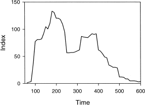

图 7.2 非洲红泥器皿进口到阿尔贝尼亚谷（伊特鲁里亚）（Bintliff 和 Sbonias 1999：5）。

Figure 7.2 Importation of African red slip ware into the Albegna Valley (Etruria) (Bintliff and Sbonias 1999:5).

帝国时期的某些经济趋势也可以通过考古数据来追踪。例如，阿尔贝尼亚山谷（伊特鲁里亚）的非洲红泥器皿进口率在公元二世纪呈增长趋势，并在 180 年代和 190 年代达到顶峰（图 7.2 ）。第三世纪崩溃之后，第四世纪最后四分之一出现了第二次高峰，反映了统治者的世俗周期。

Certain economic trends during the empire can also be traced using archaeological data. For example, the rate of importation of African red slip ware into the Albegna Valley (Etruria) exhibits an increase during the second century and reaches a peak during the 180s and 190s (figure 7.2). After the third-century collapse, a second peak occurred during the last quarter of the fourth century, reflecting the secular cycle of the Dominate.

## **社会结构与精英**

## **Social Structure and Elites**

罗马帝国的社会结构如表7.2所示。该表呈现的是静态视图，但帝国的社会结构在元首统治期间发生了巨大的变化。其中一个发展是在第二世纪出现了*诚实*和*羞辱*之间的正式法律区别，导致了塞维勒时代的“双重惩罚制度”（Saller 2000：851）。*诚实者*包括参议员、马术运动员、退伍军人及其家人。*与羞辱者*相比，他们受到的极端和有辱人格的惩罚要少一些，而且上层阶级成员的证词被认为更可信。

The social structure of the Roman Empire is sketched in table 7.2. The table presents a static view, but the social structure of the empire evolved substantially during the Principate. One development was a formal legal distinction that arose during the second century between *honestiores* and *humiliores*, resulting in the “dual penalty system” by the Severan age (Saller 2000:851). *Honestiores* included senators, equestrians, army veterans, and their families. They suffered less extreme and degrading penalties than *humiliores*, and the testimony of the upper-class members was recognized as more credible.

一个更重要的发展是整个元首制内部地位和权力等级之间的分歧日益扩大。与共和国不同，元老阶级并不垄断其手中的主要行政职位。朱利奥-克劳迪安皇帝雇用奴隶或自由民担任许多高级行政职务，例如总理大臣（Hopkins 1983）。从一世纪中叶开始，马术人员越来越多地担任这些职位。马术士大多有军事背景，成为所有重要省份的总督。“到公元三世纪末，参议院集体和大多数参议员个人都被切断了代表国家行使政治权力的权力”（Hopkins 1983：183）。

An even more important development was the increasing divergence, throughout the Principate, between the status and power hierarchies. Unlike in the Republic, the senatorial class did not monopolize the chief administrative posts in its hands. The Julio-Claudian emperors employed slaves or freedmen in a number of top administrative positions, such as heads of chancellery (Hopkins 1983). From the middle of the first century on, equestrians were increasingly employed in these positions. The equestrians, most of whom had a military background, became governors of all the important provinces. “By the end of the third century AD, the senate collectively and most senators individually were cut off from the exercise of political power on behalf of the state” (Hopkins 1983:183).

**表 7.2**

**TABLE 7.2**

一世纪罗马帝国的社会结构

Social structure of the Roman Empire during the first century

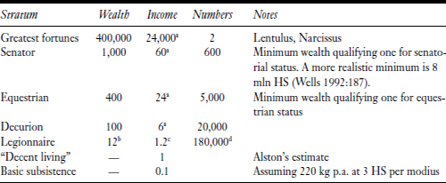

*资料来源：*参议员、马术士和十等人的数字和最低财富基于 Jongman (1988:193)；其他的则基于阿尔斯通（1998：217）。

*Source:* Numbers and minimum wealth for senators, equestrians, and decurions are based on Jongman (1988:193); others are based on Alston (1998:217).

*注：* “财富”，财产总价值；“收入”，年收入。所有数字均以 1,000 塞斯特斯为单位。

*Note:* “Wealth,” total worth of property; “Income,” annual income. All numbers in 1,000 of sesterces.

<sup>a</sup>使用 6% 的财富进行估算（Jongman 1988：195）。

<sup>a</sup> Estimate using 6% of wealth (Jongman 1988:195).

<sup>b</sup>退休奖金。

<sup>b</sup> Retirement bonus.

<sup>c</sup>年薪。

<sup>c</sup> Annual pay.

<sup>d</sup>哈尔（1996）。

<sup>d</sup> Harl (1996).

## **国家财政**

## **State Finances**

表 7.3汇总了帝国年度预算及其国库状况的零散信息。哈尔（Harl，1996：220）根据对军团士兵的工资和帝国军队数量的计算，估计了元首统治时期军队成本的螺旋式上升（图7.3a ）。年度总行政支出可能与军事费用相当，并且在奥古斯都和塞普蒂姆斯·塞维鲁统治期间可能从 4 亿先令增加到 10 亿先令（Harl 1996：227）。

Scattered indications of the empire's annual budgets and the state of its treasury are gathered in table 7.3. Basing his calculations on legionnaires’ pay and the number of troops in the empire, Harl (1996:220) estimated the spiraling costs of the military during the Principate (figure 7.3a). Total annual expenditures on administration were probably of similar magnitude to military costs, and could have increased from 400 million HS to 1 billion HS between the reigns of Augustus and Septimus Severus (Harl 1996:227).

邓肯-琼斯（Duncan-Jones，1994：11-16）指出了元首统治下帝国财政经历的四个阶段。值得注意的是，他的阶段几乎与我们在本章开头根据人口和社会政治稳定性指数描述的周期的四个阶段完全一致。

Duncan-Jones (1994:11–16) identified four phases the imperial finances went through under the Principate. Remarkably, his phases coincide almost exactly with the four phases of the cycle we delineated at the beginning of this chapter based on demographic and sociopolitical stability indices.

**表 7.3**

**TABLE 7.3**

罗马帝国的年度预算

Annual budgets of the Roman Empire

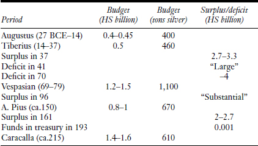

*资料来源：* Frank (1940)、Duncan-Jones (1994)、Ward 等人。（2003）。

*Source:* Frank (1940), Duncan-Jones (1994), Ward et al. (2003).

扩张阶段（公元前 27 年至公元 96 年）的特点是间歇性的财政困难，这一问题到一世纪末已基本得到解决。在奥古斯都和提比略领导下，为军队退伍奖金提供资金的困难几乎导致了叛变（Duncan-Jones 1994：11）。提比略被批评为吝啬，但他死后却在国库中积累了27亿HS。提比略的盈余随后被盖乌斯（卡里古拉）花掉，据说他死后留下了赤字。在克劳狄乌斯统治期间（41-54年），国库得到恢复，这可能得益于来自被谴责的元老和骑士的财物的资金。尼禄的统治（54-68）与卡利古拉的统治一样，花费了大量开支，但在一定程度上被大量没收财产（谴责、贵金属雕像、强迫捐款）所抵消。当维斯帕芗（Vespasian，69-79 年）成为皇帝时，他不得不应对巨额赤字（40 亿先令）。然而，尼禄所谓的挥霍行为可能是后来传统的夸大之词，后者往往指责“坏”皇帝犯下各种罪行（同样的考虑也应该对卡利古拉留下的赤字报告进行限定）。

The expansion phase (27 BCE–CE 96) was characterized by intermittent financial difficulties, which were largely resolved by the end of the first century. Difficulties in funding army discharge bonuses under Augustus and Tiberius almost led to a mutiny (Duncan-Jones 1994:11). Tiberius was criticized as being stingy, but he managed to accumulate 2.7 billion HS in the treasury by his death. Tiberius's surplus was then spent by Gaius (Caligula), who supposedly left a deficit on his death. The treasury recovered during Claudius's reign (41–54), likely helped by the funds that came from the goods of condemned senators and knights. Nero's reign (54–68), like Caligula's, saw huge expenditures that were offset to a certain degree by large seizures of property (condemnations, statues of precious metal, forced contributions). When Vespasian (69–79) became emperor, he had to deal with a huge deficit (4 billion HS). The supposed profligacy of Nero, however, may have been an exaggeration by the later tradition that tended to accuse the “bad” emperors of all kinds of sins (the same consideration should qualify the reports of the deficit left by Caligula).

维斯帕芗增加了一些税收，更新了其他已废弃的税收，并引入了新的税收。Frank (1940:53) 估计 Vespasian 统治下的年收入为 1.2-15 亿HS。换句话说，在元首制的第一个世纪里，收入增加了两倍。结果，维斯帕芗在很大程度上恢复了国家财政的健康，这使得图密善能够提高军队的军饷。尼禄统治时期第纳尔的小规模贬值被弗拉维王朝扭转了。

Vespasian increased some taxes, renewed others that had fallen into disuse, and introduced new ones. Frank (1940:53) estimated the annual income under Vespasian as 1.2–1.5 billion HS. In other words, the revenues tripled during the first century of the Principate. As a result, Vespasian largely restored the health of the state finances, which allowed Domitian to raise the army pay. The small-scale debasement of the denarius under Nero was reversed by the Flavians.

帝国进入滞胀阶段（96-165），财政状况非常强劲。图拉真（98-117）和哈德良（117-38）统治时期的特点是支出大幅增加，而收入显然很容易满足这一需求（Duncan-Jones 1994：13）。帝国资助的建筑活动在哈德良统治时期达到顶峰（Duncan-Jones 1990：图10），在图拉真和安东尼努斯·皮乌斯统治时期也非常激烈（138-61）。安东尼努斯·皮乌斯（Antoninus Pius）为他的继任者留下了巨额盈余（27亿HS）。这是五世纪之前报告的最后一次盈余（Harl 1996：94）。

The empire entered the stagflation phase (96–165) with very strong finances. The reigns of Trajan (98–117) and Hadrian (117–38) were characterized by large increases in spending that were apparently easily accommodated by the revenues (Duncan-Jones 1994:13). Imperially financed building activity reached a peak under Hadrian (Duncan-Jones 1990: Figure 10), and was also very intense under Trajan and Antoninus Pius (138–61). Antoninus Pius left a large surplus to his successors (2.7 billion HS). This was to be the last surplus reported until the fifth century (Harl 1996:94).

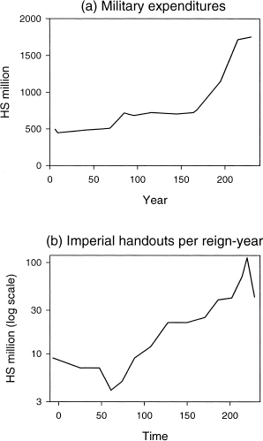

图 7.3 元首执政期间的国家支出。(a) 估计军事费用（Harl 1996：220）。(b) 帝国施舍（*congiaria*）（Duncan-Jones 1994：41）。

Figure 7.3 State expenditures during the Principate. (a) Estimated military costs (Harl 1996:220). (b) Imperial handouts (*congiaria*) (Duncan-Jones 1994:41).

帝国财政在危机阶段（165-192）崩溃。马库斯·奥勒留不得不出售皇宫的金器和艺术珍品来资助他 169 年的多瑙河战役（Ward et al. 2003:349）。*康茂德试图通过频繁而慷慨的现金发放（congiaria）*来购买人气。他每年在*congiaria*上花费约 4000 万 HS ，是哈德良 (Hadrian) 和安东尼努斯·皮乌斯 (Antoninus Pius) 领导下花费的金额的两倍（图 7.3b）。他还经常在竞技场上进行战车比赛、角斗和野兽狩猎来娱乐公民（Ward、Heichelheim 和 Yeo 2003：381）。*就其本身而言， congiaria*的支出还不足以打破国库（大概是帝国当时估计收入的 5%）。但是，向公民发放的现金补助的惊人增长至少与向军队发放的现金的增长相匹配（尽管我们缺乏该趋势的时间序列数据；参见邓肯-琼斯 (1994))。陆军费用构成了帝国预算的大部分，其增长导致了国家破产。康茂德的财政困难反映在第纳瑞斯的贬值（从 3 克白银下降到 2 克白银）以及对富有贵族的处决和没收其财产的惊人增加（Ward、Heichelheim 和 Yeo 2003： 382）。下一任皇帝佩蒂纳克斯（Pertinax，193年）再次采用变卖宫库来筹集现金的权宜之计。

The imperial finances unraveled during the crisis phase (165–192). Marcus Aurelius had to sell the gold vessels and artistic treasures of the imperial palace to finance his Danubian campaign of 169 (Ward et al. 2003:349). Commodus attempted to buy popularity by frequent and lavish cash handouts, *congiaria*. He spent around 40 million HS on *congiaria* per year, double the amount that was spent under Hadrian and Antoninus Pius (figure 7.3b). He also entertained the citizens with frequent chariot races, gladiatorial combats, and beast hunts in the arena (Ward, Heichelheim, and Yeo 2003:381). By itself, the spending on *congiaria* was not enough to break the treasury (it was perhaps 5 percent of the estimate revenues of the empire at the time). But the alarming growth of cash handouts to citizens was at least matched by the growth of handouts to the army (although we lack time-series data on this trend; see Duncan-Jones (1994)). Army costs constituted the bulk of the Imperial budget, and their growth was what caused the state bankruptcy. The financial difficulties of Commodus are reflected in the debasement of the denarius (which declined from 3 to 2 g of silver) and in the alarming increase in the executions of wealthy nobles and the confiscation of their property (Ward, Heichelheim, and Yeo 2003:382). The next emperor, Pertinax (193), again used the expedient of selling palace treasuries to raise cash.

After a brief period of relative stability under the Severi (193–235), state finances collapsed for good during the civil wars of 235–84. Probably the best indicator of the financial difficulties of the Roman state is given by the rate at which the main silver coin, the denarius, was debased by successive emperors (figure 7.4). The empire minted coins primarily for the purpose of paying the army, the bureaucracy, and making good on other state expenses. The Roman rulers recognized early on the value of debasement as a temporary solution to their fiscal difficulties. Thus, Nero reduced the silver content of the denarius (both by making it lighter and by increasing the percentage of base metal) to 3.14 g (compared to 3.72 g under Augustus). Vespasian further reduced it to 3.07 g, but once financial health was regained, Domitian increased the silver content of the denarius back to 3.28 g. While the state finances stayed healthy under the “good” emperors, the silver content of the denarius declined very slowly and was still just below 3 g under Antoninus Pius. However, by the end of the second century, the silver equivalent of the denarius had fallen precipitously to just 2 g, mainly as a result of increasing the proportion of base metal to onethird. Figure 7.4b shows the rate at which the denarius lost silver. The first peak occurred in the late second century, when Septimius Severus (193–211) became emperor and was faced with the task of stabilizing the state finances. The second peak occurred during the civil wars of 235–84. By the end of the reign of Gallienus in 272, the denarius had only 2.5 percent silver left in it.

## **社会政治不稳定**

## **Sociopolitical Instability**

从社会政治稳定和公共秩序的角度来看，元首统治时期可分为三个不同的阶段（影响政治中心的不稳定事件列表见表7.4 ）。从奥古斯都到图密善（公元前 30 年至公元 96 年）的政治不稳定主要影响到包括皇帝在内的顶级精英阶层，其中许多人被废黜和谋杀。事实上，大多数朱利奥-克劳迪安皇帝都是死于暴力。元老阶层也因在位皇帝的起诉或不成功的阴谋而遭受损失。不稳定的本质，然而，这场战争主要局限于叛国阴谋和政变，全面的内战只在 68-69 年爆发过一次。

From the point of view of sociopolitical stability and public order, the period of the Principate can be divided into three distinct phases (see table 7.4 for the list of instability events affecting the political center). Political instability from Augustus to Domitian (30 BCE–96 CE) primarily affected the top elite strata, including the emperors, many of whom were deposed and murdered. In fact, the majority of Julio-Claudian emperors died violently. The senatorial stratum also suffered as a result of prosecution from reigning emperors or following unsuccessful plots. The nature of the instability, however, was largely confined to treasonous plots and coups d'état, with full-blown civil war flaring up only once, in 68–69.

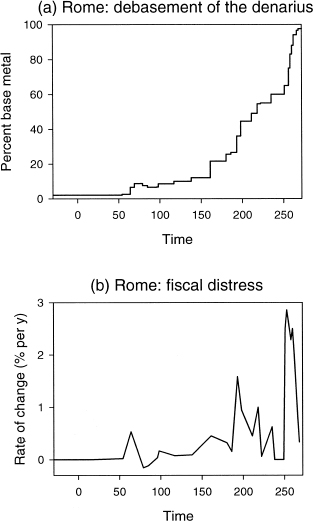

图 7.4 国家的财政困难，以第纳尔贬值的历史来说明（Duncan-Jones 1994：表 15.5）。(a) 第纳尔贬值。(b) 以每年白银含量减少率衡量的财政困境。

Figure 7.4 Financial difficulties of the state, illustrated by the debasement history of the denarius (Duncan-Jones 1994: Table 15.5). (a) Debasement of the denarius. (b) Fiscal distress measured as the rate of reduction in silver content per year.

接下来的时期，从涅尔瓦到马可·奥勒留（Marcus Aurelius，96-180），以其高度稳定性而引人注目——帝国核心意大利没有发生重大不稳定事件。第三个时期从康茂德统治时期开始，进入了高度不稳定、国家反复崩溃和内战肆虐的时期。192年至97年期间存在多方内战和多位皇帝的时期，然后从235年至285年几乎连续不断。

The next period, from Nerva to Marcus Aurelius (96–180), was remarkable for its high stability—there were no major instability events at the imperial core, Italy. The third period, starting with the reign of Commodus, introduced a time of high instability, recurrent state collapse, and endemic civil war. There were periods of multisided civil war and multiple emperors in 192–97, and then almost continuously from 235 to 285.

钱币囤积的证据（Christiansen 1985，Robertson 2000）描绘了类似的图景，但由于埋藏囤积的地点而有所不同（比较图 7.5与图 7.6和7.7）。两个省份的最高峰都发生在三世纪下半叶。次要峰显示出更多变化。亚历山大和英国在 20 世纪 60 年代都出现了高峰，这可能与 68-69 年间的内战有关。随后是 100 左右的低谷，并在安东尼皇帝统治下逐渐上升。在亚历山大，第二世纪的高峰发生在 160 年左右，比英国早。这一高峰可能与埃及起义有关。

The evidence of coin hoards (Christiansen 1985, Robertson 2000) paints a similar picture, but with variations due to localities where hoards were buried (compare figure 7.5 to figures 7.6 and 7.7). The biggest peak in both provinces occurred during the second half of the third century. The secondary peaks show more variation. In both Alexandria and Britain a peak occurred during the 60s, probably associated with the civil wars of 68–69. This was followed by a trough around 100, and a gradual rise under the Antonine emperors. In Alexandria the second-century peak occurred earlier than in Britain, around 160. This spike is perhaps associated with the Egyptian uprising.

**表 7.4**

**TABLE 7.4**

意大利社会政治不稳定，公元前 30 年至公元 285 年

Sociopolitical instability in Italy, 30 BCE–285 CE

| *年* |  | *事件* *Event* |
| --- | --- | --- |
| −22 |  | 罗马起义 Revolt at Rome |
| 15 |  | 罗马的骚乱 Disturbances at Rome |
| 24 |  | 意大利南部奴隶起义 Rebellion of the slaves in southern Italy |
| 41 |  | 卡利古拉谋杀案；克劳狄乌斯的宣言 Murder of Caligula; proclamation of Claudius |
| 42 |  | 罗马阴谋（斯克里博尼亚努斯） Conspiracy at Rome (Scribonianus) |
| 59 |  | 庞贝古城的骚乱 Disturbances at Pompeii |
| 64 |  | 罗马之火和骚乱 Fire of Rome and disturbances |
| 65 |  | 罗马的阴谋（皮索） Conspiracy at Rome (Piso) |
| 68 |  | 反抗尼禄的起义 Uprising against Nero |
| 69 |  | 三皇年；内战 Year of the three emperors; civil war |
| 95 |  | 罗马的阴谋 Conspiracy at Rome |
| 96 |  | 多米蒂安努斯被谋杀；涅尔瓦 Murder of Domitianus; Nerva |
| 182 |  | 罗马阴谋（康茂德的妹妹） Conspiracy at Rome (Commodus's sister) |
| 189 |  | 罗马的饥荒革命 Famine revolution at Rome |
| 192–97 |  | 康茂德被谋杀、内战（多个皇帝） Murder of Commodus, civil wars (multiple emperors) |
| 211 |  | 卡拉卡拉谋杀盖塔 Murder of Geta by Caracalla |
| 217 |  | 卡卡拉谋杀案 Murder of Carcalla |
| 218 |  | 马克里努斯被暗杀，内战 Macrinus assassinated, civil war |
| 221 |  | 罗马附近的军队叛变 Mutiny of army near Rome |
| 222 |  | 埃拉加巴卢斯的沉积 Deposition of Elagabalus |
| 228 |  | 罗马（和美索不达米亚）军队的骚乱 Disturbances in armies in Rome (and Mesopotamia) |
| 235–8 |  | 亚历山大·塞维鲁废黜，内战（多个皇帝） Deposition of Alexander Severus, civil war (multiple emperors) |
| 244 |  | 戈尔迪亚努斯三世谋杀案 Murder of Gordianus III |
| 248–9 |  | 叙利亚、埃及和罗马的起义；菲利普斯在战斗中阵亡 Revolts in Syria, Egypt, and at Rome; Philippus killed in battle |
| 249–53 |  | 内战（多个皇帝），加卢斯被他的军队杀死 Civil war (multiple emperors), Gallus killed by his troops |
| 258–68 |  | 内战（多位皇帝：“三十霸”） Civil war (multiple emperors: “the Thirty Tyrants”) |
| 269 |  | 博洛尼亚和其他城市的起义 Revolt at Bologna and other cities |
| 270 |  | 内战（Quintillus vs. Aurelianus） Civil war (Quintillus vs. Aurelianus) |
| 274 |  | 罗马起义（货币） Revolt at Rome (monetarii) |
| 275 |  | 奥勒良努斯遇刺后罗马的骚乱 Disturbances at Rome after the assassination of Aurelianus |
| 276 |  | 塔西佗的证词，弗洛里亚努斯 Deposition of Tacitus, Florianus |
| 282–85 |  | 内战（多个皇帝）；谋杀普罗布斯、卡里努斯 Civil war (multiple emperors); murder of Probus, Carinus |

*资料来源：*基于 Sorokin (1937)，并辅以其他资料来源。

*Source:* Based on Sorokin (1937), supplemented by other sources.

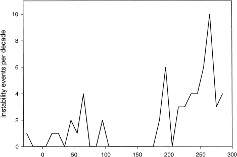

图 7.5 Roman Principate：社会政治不稳定指数（基于表 7.4中的数据）。

Figure 7.5 Roman Principate: sociopolitical instability index (based on data in table 7.4).

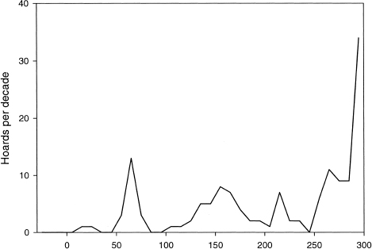

图 7.6 元首统治时期埃及亚历山大的钱币囤积时间分布（Christiansen 1985）。

Figure 7.6 Time distribution of coin hoards in Alexandria, Egypt, during the Principate (Christiansen 1985).

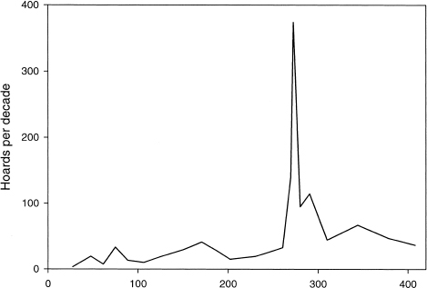

图 7.7 罗马-英国硬币囤积的时间分布（Robertson 2000）。

Figure 7.7 Time distribution of Romano-British coin hoards (Robertson 2000).

*《Corpus de Trésors Monétaires Antiques de la France》* （Société Française de Numismatique，巴黎，1982 年）中公布的钱币囤积时间分布显示了同样的广泛模式，其中一个占主导地位的 3 世纪高峰。然而，专家们将宝藏划分为非常广泛的时间类别（“第一世纪”、“第二世纪”或“胡里奥-克劳迪安”、“安东尼”），而且不同卷之间的划分也不一致，因此目前这些数据无法轻易总结。

The time distribution of coin hoards published in *Corpus de Trésors Monétaires Antiques de la France* (Société Française de Numismatique, Paris, 1982) shows the same broad pattern, with a dominant third-century peak. However, hoards have been assigned by the experts to very broad temporal categories (“first century,” “second century,” or “the Julio-Claudians,” “the Antonines”), which furthermore disagree between different volumes, so in the present form these data cannot be easily summarized.

## 7.2 扩张（公元前 27 年至公元 96 年）

## 7.2 Expansion (27 BCE–96 CE)

## **平民**

## **The Commoners**

In the previous chapter we discussed the growth of economic inequality during the late Republic. One important consequence of the civil wars and the first years of the Principate was a significant reversal of this trend. The basic precondition of reduced inequality was the population decline that took place during the first century BCE, creating space where landless peasants (mainly veterans) could be settled. For example, in 36 BCE Capua gave up large tracts of deserted land for the settlement of Octavian's veterans, in return receiving lands in Crete and funds for the construction of a new aqueduct (Wells 1992:21–22). Not all land was obtained by purchase. After the battle of Philippi (42 BCE), Octavian simply stripped eighteen towns of their land, which was divided among the veterans. One of these towns was Cremona, where perhaps 3,000–4,000 veterans were given 35 iugera (9 ha) each, a very substantial land allotment. But such land seizures stopped with the end of the civil wars. In 30 and 14 BCE Augustus spent 860 million HS to purchase land to settle veterans (of which 600 million was spent in Italy and 260 million in the provinces). Large numbers of peasants emigrating to the provinces further decreased the population pressure on resources within Italy. Additionally, Walter Scheidel (2007) estimates that under the early Principate, as many as one in ten free Italian men left Italy for service in the legions. Most of them never returned, because the surviving veterans were resettled in the provinces. However, this outlet for “demographic steam” gradually became less important, as Italian military participation rates declined during the first century.

Thus, the Principate cycle began with greater numbers of relatively prosperous small landowners compared to the late Republic. However, it is likely that this relative prosperity rapidly eroded during the first century as a result of population growth. There was also a large number of slaves in Italy (Brunt estimates 2 million, but Scheidel revises this estimate down). The number of slaves probably diminished during the first two centuries CE (Saller 2000:851). First, there was a substantial diminution of territorial conquests after Augustus, and thus the supply of war captives declined. It is thought that the slave population could not reproduce itself biologically, as a result of manumission and lower birth rates. Second, as population growth resumed, the number of landless peasants began increasing. Thus, at the same time that the price of slaves increased owing to their scarcity, the real wages that could be paid to landless peasants declined owing to their abundance, and it became more profitable to lease land in return for rent, or to hire workers.

## **精英们**

## **The Elites**

在社会规模的另一端，我们有一些零散的数字表明元老阶层的财富。我们所知道的早期帝国时期皇室以外最富有的人是公元前 14 年的执政官格奈乌斯·科尼利厄斯·伦图卢斯 (Gnaeus Cornelius Lentulus) 和克劳狄乌斯的自由民纳西索斯 (Wells 1992:8)。据称每项拥有的财产价值4亿HS。值得注意的是，这两项收入均属于元首制早期阶段。显然，第一世纪最大财富的规模有所下降，部分原因是最富有的贵族受到迫害。因此，克劳狄乌斯死后，纳西索斯被尼禄的母亲阿格里皮娜毒死。克劳狄斯（Claudius，41-54）本人判处三十五名元老和许多骑士死刑；他们的财产的很大一部分肯定进入了帝国金库（Duncan-Jones 1994：11）。据说尼禄处决了非洲六大地主，并因此获得了权力拥有富饶的布拉加达斯山谷（Ward、Heichelheim 和 Yeo 2003：322）。从65年开始，针对尼禄的阴谋不断增多，他迫使大量元老和骑士自杀。其中包括塞内卡和诗人卢坎等著名人物（Ward、Heichelheim 和 Yeo 2003：322）。

At the opposite end of the social scale we have some scattered numbers indicating the wealth of the senatorial class. The richest men outside the imperial house who are known to us from the early empire were Gnaeus Cornelius Lentulus, consul in 14 BCE, and Claudius's freedman, Narcissus (Wells 1992:8). Each reputedly owned property worth 400 million HS. It is noteworthy that both these incomes belong to the early phase of the Principate. Apparently, the scale of the largest fortunes declined during the first century, partly as a result of persecution of the wealthiest aristocrats. Thus, Narcissus was poisoned by Agrippina, Nero's mother, after Claudius's death. Claudius (41–54) himself condemned to death thirty-five senators and many knights; a substantial part of their fortunes must have gone into the imperial treasury (Duncan-Jones 1994:11). Nero is said to have executed the six largest landowners in Africa Proconsularis and thus gained possession of the rich Bragadas Valley (Ward, Heichelheim, and Yeo 2003:322). When a number of plots against Nero proliferated, starting in 65, he forced a great number of senators and equestrians to commit suicide. These included such well-known personages as Seneca and the poet Lucan (Ward, Heichelheim, and Yeo 2003:322).

As a result of imperial persecution and the civil war of 68–69, the ranks of Roman senators had become depleted to about 200 (Ward, Heichelheim, and Yeo 2003:329–30). After the purges of Nero and Domitian, most of the old Republican noble families had disappeared (Ward et al. 2003:372). Under Trajan and Hadrian only some thirty senators are known who still bore the names of the old Republican nobility (Wells 1992:171). Of the twenty-six families that Augustus (27 BCE–14 CE) and Claudius (41–54 CE) elevated to patrician status, we know of only six still surviving under Trajan (98–117 CE) (Wells 1992:237). This is a very low rate of retaining elite status, 23 percent in less than a century, implying an extinction rate per twenty-five years of well over 30 percent, perhaps close to 40 percent. Here are some additional statistics (Hammond 1957:75): the proportion of patricians of Republican ancestry who can be identified in the senate within any given period declined from an average of about 16 percent under Augustus (27 BCE–14) to 4.5 percent under Nero (54–68), slightly over 2 percent in 69, only 1 percent in 96, and less than 1 percent in 117. These numbers imply a 50 percent extinction rate per twenty-five years. Similar factors affected the descendants of emperors. For example, Junia Calvina was the only descendant of Augustus alive in the 70s (Wells 1992:67).

因此，早期元首制统治下的精英动态与都铎王朝统治下“强大的主体”的垮台非常相似（见第三章）。尽管由于帝国的迫害，国家失去了一些大量的元老财产，但当富有的元老成为皇帝时，其他人也加入了国家（例如，提图斯·奥勒留·安东尼，后来成为皇帝安东尼努斯·皮乌斯）。最终的结果是，在第一世纪，最有权势和最富有的私人的相对权力相对于国家财富而言大幅下降。

The elite dynamics under the early Principate thus resemble very much the downfall of the “overmighty subject” under the Tudors (see chapter 3). Although some large senatorial fortunes were lost to the state as a result of imperial persecution, others joined it when wealthy senators became emperors (for example, Titus Aurelius Antoninus, who became the emperor Antoninus Pius). The end result was that during the first century, the relative power of the most powerful and wealthy private individuals declined substantially with respect to the state's fortunes.

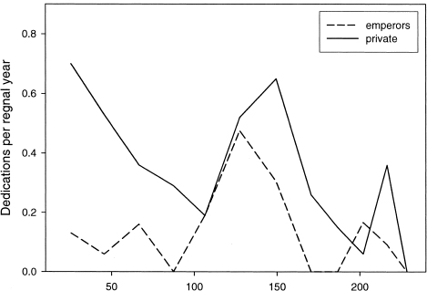

图 7.8 意大利过时建筑物的时间分布。实线：私人，虚线：皇帝（Duncan-Jones 1990：213）。

Figure 7.8 Time distribution of dated buildings in Italy. Solid line: private individuals, dashed line: emperors (Duncan-Jones 1990:213).

综上所述，顶级精英阶层——权贵们的命运，首先在元首统治时期下降，在弗拉维时期达到谷底，然后在五位贤明的皇帝统治下上升，在二世纪下半叶达到顶峰。然而，权贵阶层的性质发生了根本性的变化。第一世纪的贵族仍然由元老院统治，而在第二世纪，元老们失去了权力，并在很大程度上作为一个地位群体继续存在（Hopkins 1983：171-76）。权力积累在省长、军团军事指挥官和禁卫军指挥官手中，他们通常都是骑手。因此，元首制时期持续存在的一个重要趋势是参议院逐渐丧失作为权力精英宝库的地位。重心从元老院转移到帝国官僚机构，更准确地说转移到帝国议会。这开始于*Consilium Principis*是奥古斯都朋友和顾问的非正式秘密会议，哈德良将其转变为更永久的结构（Ward、Heichelheim 和 Yeo 2003：344）。在第二世纪，元老院逐渐失去了对帝国行政机构的任何真正影响力。在塞普蒂米乌斯·西弗勒斯 (Septimius Severus) 重组后，帝国委员会成为旧共和党参议院的真正继承者 (Ward, Heichelheim, and Yeo 2003:385)。

In summary, it appears that the fortunes of the top elite stratum, the magnates, first declined during the Principate, reaching a trough during the Flavian period, then increased under the five good emperors, reaching a peak during the second half of the second century. The nature of the magnate stratum, however, changed radically. Whereas the first century's aristocracy was still dominated by the senatorial order, during the second century senators lost power and persisted largely as a status group (Hopkins 1983:171–76). Power accumulated in the hands of provincial governors, military commanders of the legions, and the commanders of the Praetorian Guard, who typically were equestrians. Thus, one important trend that continued throughout the Principate was the senate's gradual loss of status as the repository of power elites. The center of gravity shifted from the senate to the imperial bureaucracy, and more precisely to the Imperial Council. This began as the *Consilium Principis*, an informal conclave of Augustus's friends and advisors, and was converted into a more permanent structure by Hadrian (Ward, Heichelheim, and Yeo 2003:344). During the second century the senate gradually lost any real influence on the imperial administration. The Imperial Council became the true successor of the old Republican senate after the reorganization by Septimius Severus (Ward, Heichelheim, and Yeo 2003:385).

## **（去）城市化**

## **(De)urbanization**

最后，让我们考虑一下城市化率，或者更具体地说，首都的人口规模。当局倾向于认为，从公元前二世纪末到公元前一世纪末，罗马城的人口翻了一番，达到约 800,000-1,000,000 人（Hopkins 1978:96ff., Morley 1996:36ff.）。这一估计是根据记录的免费小麦救济金和偶尔的现金发放的接受者人数（*congiaria*），在150到32万之间波动。0.8-100 万人的估计值是从 200,000-250,000 名领取者开始，除以 10 岁以上男性（有资格领取救济金的人）的估计比例，得到自由人口总数，然后加上猜测的精英阶层和奴隶阶层。然而，根据人口结构理论，记录的领取救济金的人数的波动是有意义的，我们可以利用它们来加强罗马居民人数的动态。

Finally, let us consider the urbanization rate, or, more specifically, the population size of the capital. The authorities tend to agree that the population of the city of Rome doubled from the late second to the late first century BCE, reaching around 800,000–1,000,000 (Hopkins 1978:96ff., Morley 1996:36ff.). This estimate is based on the recorded numbers of recipients of the free wheat dole and occasional cash handouts (*congiaria*), which fluctuated between 150 and 320 thousand. The estimate of 0.8–1 million is derived by starting with 200,000–250,000 recipients, dividing it by the estimated proportion of males over ten years old (those who were eligible for the dole) to obtain the total free population, and adding guessed numbers of the elite and slave strata. However, the recorded fluctuations in the numbers of dole recipients make sense in light of demographic-structural theory, and we can use them to sharpen the dynamics of the numbers of Rome's inhabitants.

记录的玉米救济金领取者人数的波动如下（Hopkins 1978：96ff，Morley 1996：36ff）。在大众论坛报 P. Clodius（公元前 50 年代）的领导下，他们的人数激增至 320,000 人。公元46年，凯撒通过组织移民到各省并加强对符合条件的人的登记，将移民人数减少到15万人。在奥古斯都统治下，人数再次增加到超过 250,000 人，并在公元前 5 年达到 320,000 人的另一个峰值。三年后，这一数字下降到略高于 200,000 人，奥古斯都去世后，玉米救济金领取者人数达到 150,000 人（至少，这是从他的遗嘱中受益的人数）。我们在这里看到了一个明确的模式：城市人口在长期的内战时期（有时间滞后）之后膨胀，然后在国内和平时期逐渐减少（见第一章）供一般性讨论）。这个论点表明我们可以从表面上理解传输的数字。那么，峰值人数 320,000 意味着居民总数约为 120 万，而谷底人数 150,000 相当于 60 万（这些估计至少存在 10% 的不确定性）。因此，我们认为，在共和国末期和奥古斯都统治初期，罗马人口增至 120 万，而到他统治末期，罗马人口已下降至 60 万。当然，在高峰时期，这座城市的人口严重过剩，而当人口在公元 14 年减半时，生活质量肯定变得更加容易忍受，即使对于较贫穷的公民阶层也是如此。

The fluctuations in the recorded numbers of corn dole recipients were as follows (Hopkins 1978:96ff, Morley 1996:36ff). Under the popularis tribune, P. Clodius (the 50s BCE), they swelled to 320,000. In 46 Caesar reduced them to 150,000 by organizing emigration to the provinces and tightening registration of those who qualified. Under Augustus the numbers increased again to more than 250,000, reaching another peak of 320,000 in 5 BCE. Three years later the numbers sank to just over 200,000, and on the death of Augustus corn dole recipients numbered 150,000 (at least, this was how many people benefited from his will). We see a definite pattern here: the urban population swells following protracted periods of civil war (with a time lag) and then is gradually reduced during periods of internal peace (see chapter 1 for the general discussion). This argument suggests that we can take the transmitted numbers at their face value. The peak number of 320,000, then, would imply some 1.2 million total inhabitants, while the trough number of 150,000 corresponds to 0.6 million (there is at least a 10 percent uncertainty associated with these estimates). We propose, therefore, that under the late Republic and during the early years of Augustus, the population of Rome swelled to 1.2 million, and by the end of his reign it had declined to 600,000. Naturally, during the peaks the city was horribly overpopulated, whereas when the population was halved, by 14 CE, the quality of life must have become much more bearable, even for the poorer citizen strata.

**表 7.5**

**TABLE 7.5**

退伍军人的工资

Legionnaires’ wages

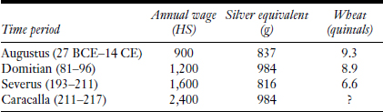

*资料来源：*名义工资来自 Greene (1986:59)，塞斯特斯 (HS) 的白银等值来自 Harl (1996)，小麦价格来自表 7.6。

*Source:* Nominal wages from Greene (1986:59), silver equivalent of sesterces (HS) from Harl (1996), and wheat prices from Table 7.6.

我们不知道罗马城的人口在第一世纪是如何变化的，但它可能没有增长太多，如果有的话（这是人口扩张阶段的一般规则，通常城市人口与城市人口的比例总量呈下降趋势）。在滞胀阶段（96-165），城市人口应该有所增加。*我们知道vici*的数量哈德良统治时期（117-38 年）至四世纪期间，城市数量有所增加。几乎可以肯定这发生在第二世纪。同样可能的是，到了第三世纪末，随着下一个统治周期的开始，罗马的人口下降了。三世纪的城墙标志着奥古斯都时代占领地区的收缩（Morley 1996：38）。总之，罗马城市人口的可能演变是从一世纪上半叶的 60 万增加到第二世纪末的 100 万以上，然后在 3 世纪末下降。

We do not know how population of the city of Rome changed during the first century, but it probably did not grow very much, if at all (that is the general rule during the population expansion phases, when typically the proportion of urban population to the total tends to decrease). During the stagflation phase (96–165), the urban population should have increased. We know that the number of *vici* in the city increased between the reign of Hadrian (117–38) and the fourth century. Almost certainly this happened during the second century. Equally likely is that by the end of the third century, with the start of the next cycle of the Dominate, the population of Rome declined. The third-century wall marked a contraction from the regions occupied during the Augustan era (Morley 1996:38). In summary, the possible evolution of the urban population of Rome was an increase from 0.6 million in the first half of the first century to perhaps well over million at the end of the second, followed by a decline toward the end of the third.

## 7.3 滞胀（公元 96-165 年）

## 7.3 Stagflation (96–165 CE)

## **人口压力与经济变化**

## **Population Pressure and Economic Change**

对于埃及以外的罗马帝国来说，价格和工资数据非常稀缺。我们所知道的唯一帝国范围内的工资是军团士兵的工资（表 7.5）。名义工资在第一和第二世纪期间翻了一番，但是当我们以白银克数表示工资时，我们发现它在第一世纪末达到顶峰，并在第二世纪下降。另一种看法是通过使用埃及价格将工资换算成小麦（见下文）。根据这一衡量标准，士兵工资仅能勉强补偿第一世纪的通货膨胀（9.3 和 8.9 公担之间的差异小于与估计实际工资相关的不确定性）。

Price and wage data are very scarce for the Roman Empire outside Egypt. The only empire-wide wages we know about are those of the legionnaires (table 7.5). The nominal wage doubled during the first and second centuries, but when we express the wage in terms of grams of silver, we observe that it peaked at the end of the first century and declined during the second. Yet another look is afforded by translating the wage into wheat, using the Egyptian prices (see below). According to this measure, the soldier wages just barely compensated for inflation during the first century (the difference between 9.3 and 8.9 quintals is less than the uncertainty associated with estimating the real wage).

我们有一些罗马帝国经济趋势记录的地区之一是埃及。表 7.6 显示了公元前三个世纪小麦价格的变化。

One area of the Roman Empire for which we have some documentation of economic trends is Egypt. Table 7.6 shows changes in the price of wheat during the first three centuries CE.

|  | **表 7.6** **TABLE 7.6** |  |  |  |
| --- | --- | --- | --- | --- |
|  | 埃及小麦价格（按时期平均） Wheat prices in Egypt (averages by period) |  |  |  |
|  | *时间段* | *阿尔塔巴德拉克马* | *银（克每公担）* |  |
|  | 私人交易 |  |  |  |
|  | 公元前 18 年 – 公元 47 年 | 7.2 | 90 |  |
|  | 公元 78–79 年 | 10.6 | 116 |  |
|  | 公元 112–135 年 | 10.0 | 105 |  |
|  | 公元 150–200 年 | 15.3 | 124 |  |
|  | 公元 250–300 年 | 42.9 | 44 |  |
|  | 官方价格 |  |  |  |
|  | 公元前 13 年 – 公元 65 年 | 3.3 | 42 |  |
|  | 公元 99–162 年 | 9.0 | 94 |  |
|  | 公元 246–294 年 | 146 | 73 |  |
|  | *资料来源：*基于 Duncan-Jones (1990:151–55) 中的数据。 *Source:* Based on data in Duncan-Jones (1990:151–55). |  |  |  |

私人交易和官方价格都讲述了同样的故事。到二世纪下半叶，小麦的名义价格翻了一番甚至更多。这种趋势不仅仅是由于二世纪罗马硬币的贬值（见下文），因为以白银单位表示的小麦价格也上涨了。在第三世纪，小麦的名义价格持续上涨，到最后一个季度达到每阿塔巴 200-300 德拉克马（Duncan-Jones 1990），但这种上涨似乎完全是由于贬值造成的。当以白银等价物表示时，我们看到小麦的价格实际上在三世纪下降了。

Both private transactions and official prices tell the same story. The nominal price of wheat doubled or more toward the second half of the second century. This trend was not due just to the debasement of Roman coins during the second century (see below), because the price of wheat also increased when expressed in silver units. During the third century, the nominal price of wheat continued to rise, reaching 200–300 drachmas per artaba by the last quarter (Duncan-Jones 1990), but it appears that this increase was entirely due to debasement. When expressed in silver equivalents, we see that the price of wheat actually declined in the third century.

Scheidel (2002) 是埃及第二世纪和第三世纪经济趋势的最新汇编。沙伊德尔报告了土地价格、土地租金、小麦和其他商品价格以及工资的名义和实际价格的平均值和中位数。实际（紧缩）价值特别令人感兴趣，因为在此期间由于第纳尔贬值而导致的快速通货膨胀（见下一节）使得名义价值无法提供信息。例如，埃及有一些农业土地价格的数据，但对这些数据的解释引起了一些争议。Duncan-Jones (1974) 给出了表 7.7中的数据。中位数先增加然后减少，这从人口结构角度来看是有意义的。考虑到银币的贬值，第三世纪的下降可能更为严重。然而，邓肯-琼斯观察到，在此期间最高价格和最低价格都在持续上涨。这种趋势让人对中位价格中观察到的趋势的有效性产生怀疑。Alston（1995）试图分别追踪“低质量”、“平均”和“高质量”土地的价格趋势。Scheidel (2002) 使用了两个类别（每个 aroura 少于或多于 600 德拉克马）。两者都受到 Bagnall (2005) 的严厉批评。因此，下面我们重点关注实际租金（还有一些关于第二世纪到第三世纪实际工资变化的信息，我们将在第 7.4 节中回顾）。

The best recent compilation of economic trends in Egypt during the second and third century is in Scheidel (2002). Scheidel reports on the means and medians of land prices, land rents, wheat and other commodity prices, and wages, in both nominal and real terms. The real (deflated) values are of particular interest, because rapid inflation due to debasement of the denarius during this period (see next section) makes nominal values uninformative. For example, there are some data on agricultural land prices in Egypt, but the interpretation of what these data tell us generated some controversy. Duncan-Jones (1974) gave the data in table 7.7. The median first increases and then decreases, which would make sense in demographic-structural terms. The third century decrease was probably even more profound, given the debasement of silver coinage. However, Duncan-Jones observed that both maximum and minimum prices kept increasing throughout the period. This trend throws doubt on the validity of the trend observed in the median price. Alston (1995) attempted to trace price trends separately in “low-quality,” “average,” and “high-quality” land. Scheidel (2002) instead used two categories (less or more than 600 drachmas per aroura). Both were roundly criticized by Bagnall (2005). For this reason, in the following we focus on real rents (there is also some information on the change in real wages from the second to the third century, which we review in section 7.4).

**表 7.7**

**TABLE 7.7**

每 iugerum 的土地价格（以塞斯特斯 (HS) 为单位）

Land prices in sesterces (HS) per iugerum

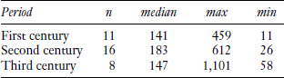

*资料来源：*邓肯-琼斯 (1974:366)。

*Source:* Duncan-Jones (1974:366).

**表 7.8**

**TABLE 7.8**

麦田平均年实际土地租金（artabas per aroura）

Mean annual real land rents for wheat fields (artabas per aroura)

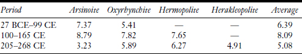

*资料来源：* Scheidel（2002 年：表 1）。

*Source:* Scheidel (2002: table 1).

*注：*仅显示平均值；中位数显示出相同的趋势。基于 133 个数据点。

*Note:* Only means are shown; medians show the same trend. Based on 133 data points.

所有地区的实际租金变化都是一致的，从公元一世纪到公元 165 年（瘟疫前夕）呈上升趋势，随后在公元三世纪下降。瘟疫后人口平均下降 37%，表明流行病和社会政治不稳定导致人口大幅减少。

Changes in real rents are consistent among all regions and show an increase from the first century toward 165, the eve of the plague, followed by a decrease in the third century. The post-plague decline on average is 37 percent, suggesting a substantial population decrease resulting from epidemics and sociopolitical instability.

## **精英生产过剩和竞争**

## **Elite Overproduction and Competition**

In the previous chapter we used the statistics of Hopkins and Burton on consular ascendance and descendance rates to argue for an increasing intraelite competition toward the end of the Republican cycle. We are lucky in that these authors have also provided similar statistics for the Principate period. However, there are several caveats we need to take in consideration when considering these numbers. First, whereas the consuls of the Republican period were at the pinnacle of both the status and power pyramids, during the Principate they retained only status, while power passed into the hands of emperors and their top administrators, who by the end of the period were recruited almost entirely outside the senatorial order (mainly from the equestrians). Second, the data are much sparser than those for the Republic because Hopkins and Burton elected to investigate only every other generation of the consular aristocracy. Thus, instead of having eight data points to cover the period of the Principate, we have only four. Third, whereas under the Republic the number of men elected to consulship in any generation stayed roughly constant, because only two consuls could be elected in a year, during the Principate the number of consuls elected per year increased gradually to eight or ten under the last Antonines. This increase obviously affects the conclusions we draw from the difference between proportions of consuls with consular ascendants and descendants. As a result of these caveats, our conclusions below are much more tentative than in the previous chapter. The main problem is the sparsity of data; it would be extremely useful to complete the work of Hopkins and Barton by filling in the missing generations.

**表 7.9**

**TABLE 7.9**

元首领事地位的继承

Inheritance of consular status under the Principate

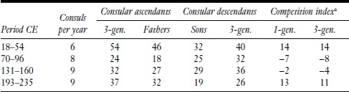

*资料来源：* Hopkins 和 Barton 的数据，来自 Hopkins (1983)。

*Source:* Data of Hopkins and Barton, from Hopkins (1983).

*注：* “3 代”。指三代祖先（曾祖父、祖父、父亲）或后代（儿子、孙子、曾孙）。“第一代。” 要么是父亲，要么是儿子。

*Note:* “3-gen.” refers to three generations of ascendants (great-grandfather, grandfather, father) or descendants (son, grandson, great-grandson). “1-gen.” is either a father or a son.

<sup>a</sup> Competition index is determined as the proportion with consular ascendants minus the proportion with consular descendants

到了第二世纪，这种趋势发生了逆转，父亲为领事的执政官比例从 18% 上升到 27%，然后又上升到 32%。因此，世袭贵族重新确立了对领事职位的控制，尽管它从未达到 18-54 年（或公元前二世纪，正如我们在上一章中讨论的那样）的控制水平。

In the second century the trend inverted, and the proportion of consuls with consular fathers climbed from 18 to 27 percent and then to 32 percent. The hereditary aristocracy thus was reasserting its grip on consular positions, although it never reached the same level of control it had in 18–54 (or during the second century BCE, as we discussed in the previous chapter).

基于这些数据的任何结论都必须保持试探性，直到填补空白。但是数据模式，尤其是竞争指数，与我们在第 7.2 节（“精英”）中的叙述一致，我们在该节中认为，在元首执政期间，上层精英阶层的财富先是下降，在弗拉维王朝时期达到最低谷，然后在五位贤明的皇帝统治下上升，在二世纪下半叶达到顶峰。从马库斯·奥勒留，尤其是康茂德开始，我们观察到精英生产过剩和竞争加剧的迹象，最终导致了二世纪末的国家崩溃。

Any conclusions based on these data must remain tentative until the gaps are filled in. But the data patterns, and especially the competition index, are consistent with our narrative in section 7.2 (“Elites”), where we argued that during the Principate, the fortunes of the top elite stratum first declined, reaching a trough during the Flavian period, then increased under the five good emperors, reaching a peak during the second half of the second century. Beginning with Marcus Aurelius and, especially, Commodus, we observe signs of elite overproduction and increased competition that eventually contributed to the state breakdown in the late second century.

精英生产过剩的一个典型标志是行政职位的增加。根据 HG Pflaum（霍普金斯 1983：180 引用）的说法，在图密善（81-96）统治时期，各省有 64 个马术哨所，在塞普蒂米乌斯·塞维鲁（193-211）统治时期，有 173 个。因此，尽管在第二世纪帝国领土扩张的程度微乎其微（有些地方甚至有所收缩），但行政职位的数量几乎增加了三倍，这或许反映了剩余精英对政府职位的压力。

One typical sign of elite overproduction is the growth of administrative posts. According to H. G. Pflaum (cited in Hopkins 1983:180), there were 64 equestrian posts in the provinces in the reign of Domitian (81–96) and 173 in the reign of Septimius Severus (193–211). Thus, although during the second century the territory of the empire expanded to a very insignificant degree (and in places even contracted), the number of administrative posts grew almost threefold, perhaps reflecting pressure from the surplus elites for government positions.